# concentration_detection_model

Here we are instaliing the pytorch

```python
!pip3 install torch torchvision torchaudio --index-url https://download.pytorch.org/whl/cu117
```

cloning the yolov5

```python
!git clone https://github.com/ultralytics/yolov5
```

```
fatal: destination path 'yolov5' already exists and is not an empty directory.
```

installing the importatnt requirements

```python
!cd yolov5 & pip install -r requirements.txt
```

importing intial dependencies

*matplotlib:- is used for visulizing the images

*numpy:-is used for array transformation

*torch :- is used to load the YOLO model

*cv2:-is used to help access webcam

```python
import numpy as np
from matplotlib import pyplot as plt
import cv2
import torch
import os
import time
import os
import uuid
```

we are now loading the YOLOV5s

```python
pretrained_model = torch.hub.load('ultralytics/yolov5', 'yolov5s', pretrained=True)
```

```
Using cache found in C:\Users\joshi/.cache\torch\hub\ultralytics_yolov5_master
YOLOv5  2023-6-12 Python-3.11.2 torch-2.0.1+cu117 CUDA:0 (NVIDIA GeForce RTX 3070 Laptop GPU, 8192MiB)

Fusing layers...
YOLOv5s summary: 213 layers, 7225885 parameters, 0 gradients
Adding AutoShape...
```

```
@software{yolov5,
  title = {YOLOv5 by Ultralytics},
  author = {Glenn Jocher},
  year = {2020},
  version = {7.0},
  license = {AGPL-3.0},
  url = {https://github.com/ultralytics/yolov5},
  doi = {10.5281/zenodo.3908559},
  orcid = {0000-0001-5950-6979}
}
```

```python
pretrained_model
```

[output not shown]

[output cut: 251 more lines]

[output not shown]

```python
figs = ['C:\pj2\yolov5\data\images\people.JPG']
```

```python
outcome = pretrained_model(figs)
outcome.print()
```

```
image 1/1: 2760x4141 19 persons, 2 cars, 2 buss, 6 traffic lights, 1 backpack, 1 umbrella, 1 book
Speed: 264.8ms pre-process, 97.4ms inference, 22.6ms NMS per image at shape (1, 3, 448, 640)
```

```python
outcome.render()
```

[output not shown]

The first value, 1, indicates the number of images in the array. In this case, there is only one image in the array.

```python
np.array(outcome.render()).shape
```

```
(1, 2760, 4141, 3)
```

```python
np.squeeze(outcome.render()).shape
```

```
(2760, 4141, 3)
```

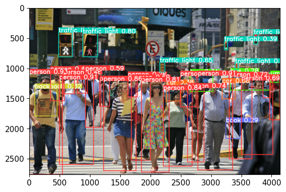

```python
%matplotlib inline
fig = np.squeeze(outcome.render())
plt.imshow(fig)
plt.show()
```

Now we will do the real-time detection

```python
def frame_processing(input):
    outcome = pretrained_model(input)
    cv2.imshow('Detection Model', np.squeeze(outcome.render()))

seize = cv2.VideoCapture('Car Crash Compilation _ Dashcam Videos _ Driving Fails  - 266 [USA & Canada Only].mp4')
while True:
    value_returned, input = seize.read()

    if not value_returned:
        break

    frame_processing(input)

    if cv2.waitKey(15) == ord('b'):
        break

seize.release()
cv2.destroyAllWindows()
```

Image Capturing

```python
pathoffigures = 'essentials/images'
tags = ['concentrated', 'distracted']
numoffigs = 40
```

```python
seize = cv2.VideoCapture(0)
for tag in tags:
    print(f"Acquiring images for the {tag}")
    time.sleep(5)
    for fignum in range(numoffigs):
        print(f"Acquiring images for the {tag}, number of image {fignum}")
        value_returned, input = seize.read()
        #here we are using uuid to name the images as if we use fignum new images
        #are overwriting the older ones
        nameoffig = pathoffigures + '/' + tag + '.' + str(uuid.uuid1()) + '.jpg'
        cv2.imwrite(nameoffig, input)
        cv2.imshow('Image Collection', input)
        time.sleep(5)
        if cv2.waitKey(5) == ord('b'):
            break
seize.release()
cv2.destroyAllWindows()
```

```
Acquiring images for the concentrated
Acquiring images for the concentrated, number of image 0
Acquiring images for the concentrated, number of image 1
```

labelled image package for labelling

```python
!git clone https://github.com/tzutalin/labelImg
```

```
fatal: destination path 'labelImg' already exists and is not an empty directory.
```

PyQt5 is a Python binding for the Qt application framework, which allows you to create desktop applications with a graphical user interface. and lxml is the another package we want to install which is a library for processing XML and HTML documents in Python and it's a dependancy of Pyqt5.

```python
!pip install pyqt5 lxml --upgrade
```

This command is for working with resouces.qrc file in labelimg it is a part of standard installation code for labelimg which can ve found on lalbelmg's git repository.

```python
!cd labelImg && pyrcc5 -o libs/resources.py resources.qrc
```

training command ,also here we are here droping the number of worker using by pytorch at a particular time in order to solve broken pipe error

```python
 !cd yolov5 && python train.py --img 320 --batch 16 --epochs 700 --data joshi.yaml --weights yolov5s.pt --workers 2
```

[output not shown]

[output cut: 24494 more lines]

```
Fusing layers...
Model summary: 157 layers, 7055974 parameters, 0 gradients, 15.9 GFLOPs

                 Class     Images  Instances          P          R      mAP50   mAP50-95:   0%|          | 0/7 [00:00<?, ?it/s]
                 Class     Images  Instances          P          R      mAP50   mAP50-95:  14%|#4        | 1/7 [00:00<00:01,  4.66it/s]
                 Class     Images  Instances          P          R      mAP50   mAP50-95:  29%|##8       | 2/7 [00:00<00:01,  4.14it/s]
                 Class     Images  Instances          P          R      mAP50   mAP50-95:  43%|####2     | 3/7 [00:00<00:01,  3.95it/s]
                 Class     Images  Instances          P          R      mAP50   mAP50-95:  57%|#####7    | 4/7 [00:00<00:00,  3.97it/s]
                 Class     Images  Instances          P          R      mAP50   mAP50-95:  71%|#######1  | 5/7 [00:01<00:00,  4.17it/s]
                 Class     Images  Instances          P          R      mAP50   mAP50-95:  86%|########5 | 6/7 [00:01<00:00,  4.69it/s]
                 Class     Images  Instances          P          R      mAP50   mAP50-95: 100%|##########| 7/7 [00:01<00:00,  4.78it/s]
                   all        209        209      0.999          1      0.995      0.991
          concentrated        209        109      0.999          1      0.995      0.987
            distracted        209        100          1          1      0.995      0.995
Results saved to runs\train\exp16
```

Now we are loading the custom model

```python
#force_reload=True ensures that the model is loaded even if a previously loaded model exists.
custom_model = torch.hub.load('ultralytics/yolov5', 'custom', path='yolov5/runs/train/exp16/weights/last.pt', force_reload=True)
```

```
Downloading: "https://github.com/ultralytics/yolov5/zipball/master" to C:\Users\joshi/.cache\torch\hub\master.zip
YOLOv5  2023-6-12 Python-3.11.2 torch-2.0.1+cu117 CUDA:0 (NVIDIA GeForce RTX 3070 Laptop GPU, 8192MiB)

Fusing layers...
Model summary: 157 layers, 7055974 parameters, 0 gradients, 15.9 GFLOPs
Adding AutoShape...
```

```python
custom_model
```

[output not shown]

[output cut: 251 more lines]

[output not shown]

```python
def frame_processing(input):
    outcome = custom_model(input)
    cv2.imshow('Detection Model', np.squeeze(outcome.render()))

seize = cv2.VideoCapture(0)
while True:
    value_returned, input = seize.read()

    if not value_returned:
        break

    frame_processing(input)

    if cv2.waitKey(15) == ord('b'):
        break

seize.release()
cv2.destroyAllWindows()
```